# negatron_analyses

Ann E. Nordmeyer

July 3, 2016

```r
library(dplyr)
```

```r
library(ggplot2)
library(lme4)
library(bootstrap)
library(grid)
library(knitr)
```

## Quick Summary

Participants were randomly assigned to be either speakers (complete the sentence task; n = 266) or listeners (truth value judgment task; n = 186). Context condition indicates the proportion of characters holding items (e.g., how many of the four boys were holding apples). Context varied within subjects.

This is an example of what a trial looked like:

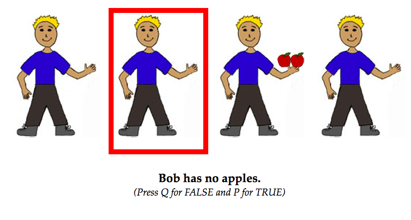

Here are the speaker data:

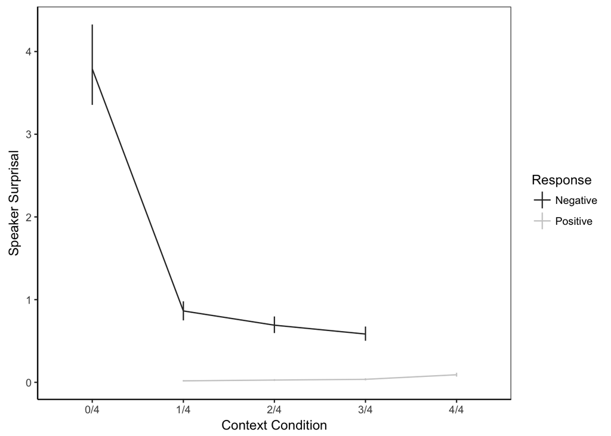

Here are the listener data:

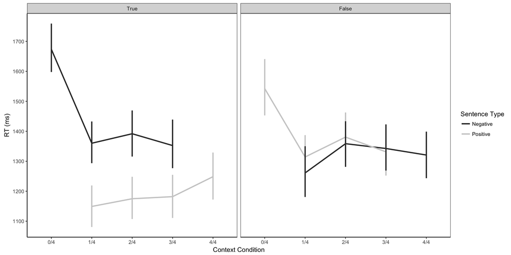

## Full analyses

Analyses for a previous, unpublished version of the experiments described in Nordmeyer & Frank, “Negation is only hard to process when it is not relevant or informative”.

These experiments were identical to the published experiments, except that the characters were identical except for the presence or absence of items (in the version described in the paper, characters also differed in shirt/hair color). These unpublished experiments can be viewed here:

Listener Condition: http://anordmey.github.io/negatron/unpublished/unpublished_experiments/listeners/negatron.html

Speaker Condition: http://anordmey.github.io/negatron/unpublished/unpublished_experiments/speakers/negatron.html

## Setting up

Functions and add some style elements for ggplot2.

```r
## number of unique subs
n.unique <- function (x) {
  length(unique(x))
}

#for bootstrapping 95% confidence intervals
theta <- function(x,xdata) {mean(xdata[x])}
ci.low <- function(x) {
  quantile(bootstrap(1:length(x),1000,theta,x)$thetastar,.025)}
ci.high <- function(x) {
  quantile(bootstrap(1:length(x),1000,theta,x)$thetastar,.975)}

#Plot style
plot.style <- plot.style <- theme_bw() + theme(panel.grid.minor=element_blank(), panel.grid.major=element_blank(), legend.position="right", axis.line = element_line(colour="black",size=.5), axis.ticks = element_line(size=.5), axis.title.x = element_text(vjust=-.5), axis.title.y = element_text(angle=90,vjust=0.25))
```

## Speaker condition

### Prep speaker data

Load in data:

```r
##Load in speaker data
d.speakers <- read.csv("./data/speakers_long.csv")
d.speakers$subid <- as.factor(d.speakers$subid)
```

Recode context. Context was initially coded as # of context characters with target item. Here we recode as total number of characters (including referent) with target items.

```r
d.speakers$recode.context <- paste(as.character(d.speakers$context.condition),"/4",sep = "")
d.speakers[d.speakers$trial.type == "item",]$recode.context <- paste(as.character(d.speakers[d.speakers$trial.type == "item",]$context.condition + 1),"/4",sep="")
d.speakers$recode.context <- factor(d.speakers$recode.context)
```

Simplify coding scheme. In the initial coding scheme, we had multiple codes:  
Several negation codes (empty, no, not, nothing, without, zero).  
Several positive codes (“othernoun” is descriptions of a noun other than the target noun, e.g. “Bob has a table”).  
Several other codes (“body” is descriptions of the character’s body, “clothing” is descriptions of the character’s clothing).

In the paper, we use a more conservative coding scheme, to strictly parallell the sentences seen in the listener condition.  
Only instances of “no x” are coded as “negation”.  
Only descriptions of the target objects are coded as “noun”.  
Everything else is coded as “other”.

```r
#toggling the commented lines will let you see how the data looks if you include other instances of negation. A discussion of how this influences the findings can be found in the speaker results section of the paper.
d.speakers$code.cat <- "Other"
d.speakers[d.speakers$coding == "no",]$code.cat <- "Negation"
#d.speakers[d.speakers$coding == "not",]$code.cat <- "Negation"
#d.speakers[d.speakers$coding == "without",]$code.cat <- "Negation"
#d.speakers[d.speakers$coding == "zero",]$code.cat <- "Negation"
#d.speakers[d.speakers$coding == "nothing",]$code.cat <- "Negation"
d.speakers[d.speakers$coding == "noun",]$code.cat <- "Noun"
d.speakers$code.cat <- factor(d.speakers$code.cat)
```

n = 266 participants in speaker condition.

### Speaker Plots

Table of mean probabilities:

```r
##Means by subject
ms.speakers <- rbind_list(
  d.speakers %>%
    group_by(recode.context, trial.type, subid) %>%
    summarise(count = mean(code.cat == "Negation"), code.cat = "Negative"),
  d.speakers %>%
    group_by(recode.context, trial.type, subid) %>%
    summarise(count = mean(code.cat == "Noun"), code.cat = "Positive")
) %>%
  group_by(recode.context, trial.type, code.cat) %>%
  summarise(m.cih = ci.high(count),
            m.cil = ci.low(count),
            m = mean(count))
names(ms.speakers) <- c("context","trial.type","sentence.type","m.cih","m.cil","m")
ms.speakers$sentence.type <- factor(ms.speakers$sentence.type, levels=c("Negative","Positive"))

kable(ms.speakers, digits = 2)
```

| context | trial.type | sentence.type | m.cih | m.cil | m |
| --- | --- | --- | --- | --- | --- |
| 0/4 | nothing | Negative | 0.03 | 0.01 | 0.02 |
| 0/4 | nothing | Positive | 0.02 | 0.01 | 0.02 |
| 1/4 | item | Negative | 0.00 | 0.00 | 0.00 |
| 1/4 | item | Positive | 0.99 | 0.97 | 0.98 |
| 1/4 | nothing | Negative | 0.47 | 0.38 | 0.42 |
| 1/4 | nothing | Positive | 0.03 | 0.01 | 0.02 |
| 2/4 | item | Negative | 0.01 | 0.00 | 0.00 |
| 2/4 | item | Positive | 0.98 | 0.96 | 0.97 |
| 2/4 | nothing | Negative | 0.55 | 0.45 | 0.50 |
| 2/4 | nothing | Positive | 0.03 | 0.00 | 0.02 |
| 3/4 | item | Negative | 0.01 | 0.00 | 0.00 |
| 3/4 | item | Positive | 0.98 | 0.95 | 0.96 |
| 3/4 | nothing | Negative | 0.60 | 0.51 | 0.56 |
| 3/4 | nothing | Positive | 0.03 | 0.00 | 0.01 |
| 4/4 | item | Negative | 0.00 | 0.00 | 0.00 |
| 4/4 | item | Positive | 0.93 | 0.89 | 0.91 |

Probability of producing a negative sentence on nothing trials (e.g., “no apples” when you see a person with nothing) or a positive sentence on item trials (e.g., “apples” when you see a person with apples); compare to Figure 2 in paper:

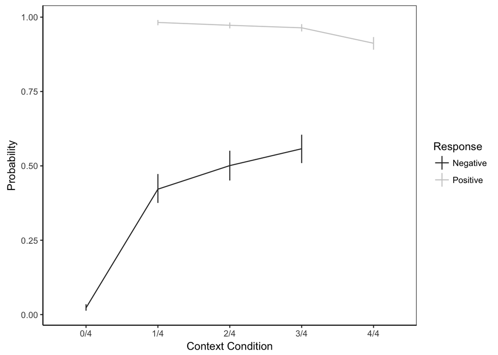

```r
qplot(context, m, group = sentence.type,
      ymin = m.cil, ymax = m.cih,
      col = sentence.type,
      geom = c("line","linerange"),
      data = subset(ms.speakers, (sentence.type == "Negative" & trial.type == "nothing") |
                      (sentence.type == "Positive" & trial.type == "item"))) +
  ylab("Probability") +
  xlab("Context Condition") +
  scale_colour_grey("Response") +
  #xlim(c(0,1)) +
  plot.style
```

Surprisal (-log(prob)) of producing a negative sentence on nothing trials (e.g., “no apples” when you see a person with nothing) or a positive sentence on item trials (e.g., “apples” when you see a person with apples); compare to Figure 3 in paper.

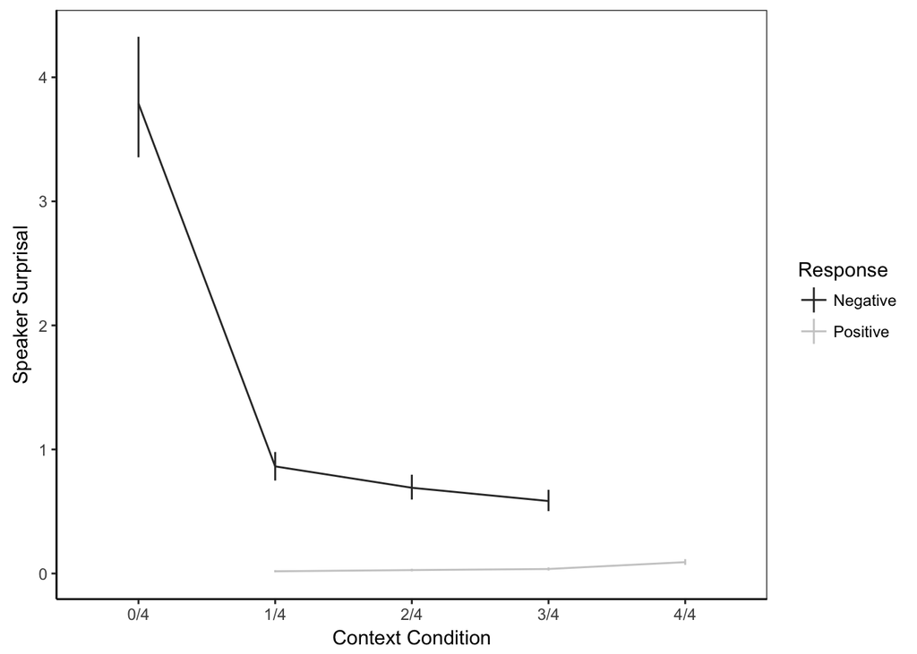

```r
qplot(context, -log(m), group = sentence.type,
      ymin = -log(m.cil), ymax = -log(m.cih),
      col = sentence.type,
      geom = c("line","linerange"),
      data = subset(ms.speakers, (sentence.type == "Negative" & trial.type == "nothing") |
                      (sentence.type == "Positive" & trial.type == "item"))) +
  ylab("Speaker Surprisal") +
  xlab("Context Condition") +
  scale_colour_grey("Response") +
  #xlim(c(0,1)) +
  plot.style
```

### Speaker Models

First, recode context in two ways. numeric.context is the numeric proportion of characters with target items in the context. dummy.context compares the 0/4 context to all other contexts.

```r
d.speakers$dummy.context <- 0
d.speakers[d.speakers$recode.context == "0/4",]$dummy.context <- 1

d.speakers$numeric.context <- as.numeric(as.character(factor(d.speakers$recode.context, levels=c("0/4","1/4","2/4","3/4","4/4"), labels=c(0, .25, .5, .75, 1))))
```

Look at effect of context on probability of producing a negative sentence on a nothing trial (e.g. probability of producing true negative sentence):

```r
d.speakers$negation <- 0
d.speakers[d.speakers$code.cat == "Negation",]$negation <- 1

#Random slopes model does not converge
model.neg.nothing <- glmer(negation ~ dummy.context + numeric.context
                + (1 | subid)
                + (1 | item),
                data=filter(d.speakers, trial.type == "nothing"), family = "binomial")
kable(summary(model.neg.nothing)$coefficients, digits = 2)
```

|  | Estimate | Std. Error | z value | Pr(>\|z\|) |
| --- | --- | --- | --- | --- |
| (Intercept) | -1.18 | 0.23 | -5.22 | 0 |
| dummy.context | -4.91 | 0.31 | -16.02 | 0 |
| numeric.context | 2.19 | 0.26 | 8.50 | 0 |

Look at effect of context on probability of producing a positive sentence about the target item (i.e. “apples”) on item trials.

```r
#Random slopes model does not converge
d.speakers$noun <- 0
d.speakers[d.speakers$code.cat == "Noun",]$noun <- 1

model.pos.item <- glmer(noun ~ numeric.context
                           + (1 | subid)
                           + (1 | item),
                           data=filter(d.speakers, trial.type == "item"), family = "binomial")
kable(summary(model.pos.item)$coefficients, digits = 2)
```

|  | Estimate | Std. Error | z value | Pr(>\|z\|) |
| --- | --- | --- | --- | --- |
| (Intercept) | 6.12 | 0.37 | 16.39 | 0 |
| numeric.context | -2.72 | 0.35 | -7.86 | 0 |

## Listener condition

### Prep listener data

Load in data:

```r
##Load in listener data
d.listeners <- read.csv("./data/listeners_long.csv")
d.listeners$subid <- as.factor(d.listeners$subid)

d.listeners$truth.value <- as.numeric(d.listeners$response)
d.listeners[d.listeners$correct == 0,]$truth.value <- 1 - as.numeric(d.listeners[d.listeners$correct == 0,]$response)
d.listeners$truth.value <- as.factor(as.logical(d.listeners$truth.value))

d.listeners$text.condition <- factor(d.listeners$text.condition,levels=c("positive","negative"), labels=c("Positive","Negative"))
d.listeners$response <- factor(d.listeners$response,levels=c("TRUE","FALSE"))
```

Recode context. Context was initially coded as # of context characters with target item. Here we recode as total number of characters (including referent) with target items.

```r
tpresent <- d.listeners %>%
  filter((text.condition == "Positive" & response == TRUE) |
           (text.condition == "Negative" & response == FALSE)) %>%
  mutate(recode.context = paste(as.character((context.condition + 1)), "/4", sep=""))

tabsent <- d.listeners %>%
  filter((text.condition == "Negative" & response == TRUE) |
           (text.condition == "Positive" & response == FALSE)) %>%
  mutate(recode.context = paste(as.character(context.condition), "/4", sep=""))

d.listeners <- rbind(tpresent, tabsent)
d.listeners$recode.context <- as.factor(d.listeners$recode.context)
```

Look at accuracy across trial types, then remove people with less than 80% accuracy:

```r
#Accuracies across trial types:
acc <- d.listeners %>%
  group_by(truth.value, text.condition) %>%
  summarize(mean = mean(correct))
kable(acc, digits = 2)
```

| truth.value | text.condition | mean |
| --- | --- | --- |
| FALSE | Positive | 0.95 |
| FALSE | Negative | 0.96 |
| TRUE | Positive | 0.98 |
| TRUE | Negative | 0.92 |

```r
#Now reject anyone with less than 80% correct
propcorrect <- aggregate(correct~subid, data=d.listeners, mean)

reject <- propcorrect[propcorrect$correct < .8,]

for (i in reject$subid) {
    d.listeners<-d.listeners[d.listeners$subid != i,]
}
```

Remove incorrect trials & trim outliers.

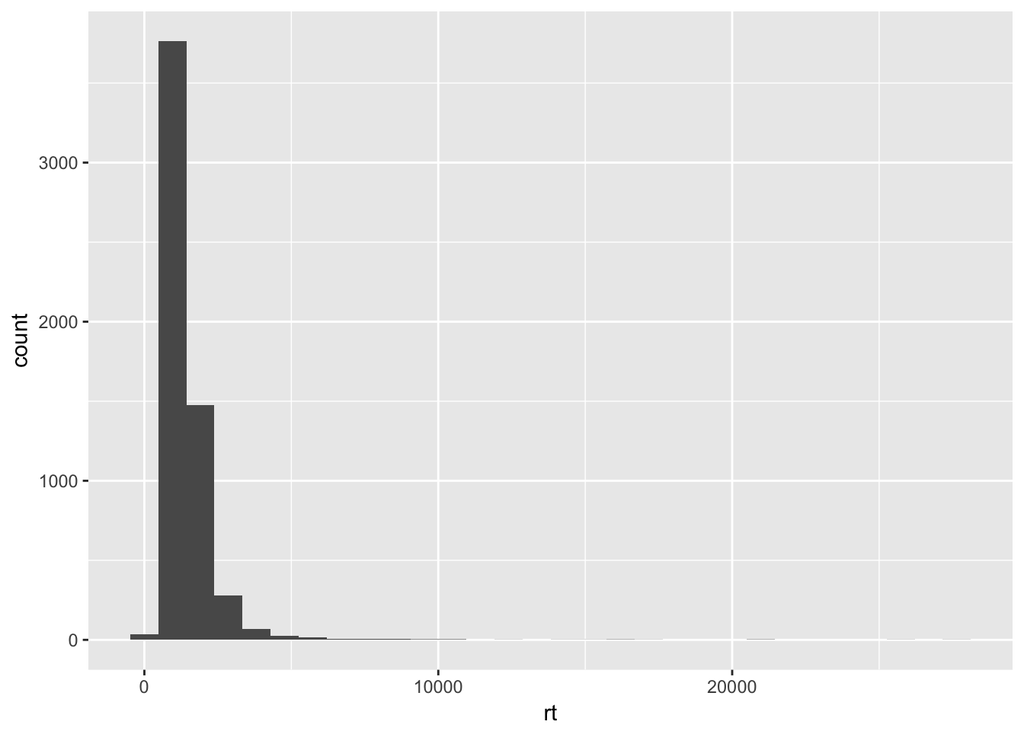

```r
#Remove incorrect
d.listeners.c <- d.listeners[d.listeners$correct == 1,]

#LogRT
qplot(data=d.listeners.c, x=rt, geom="histogram")
```

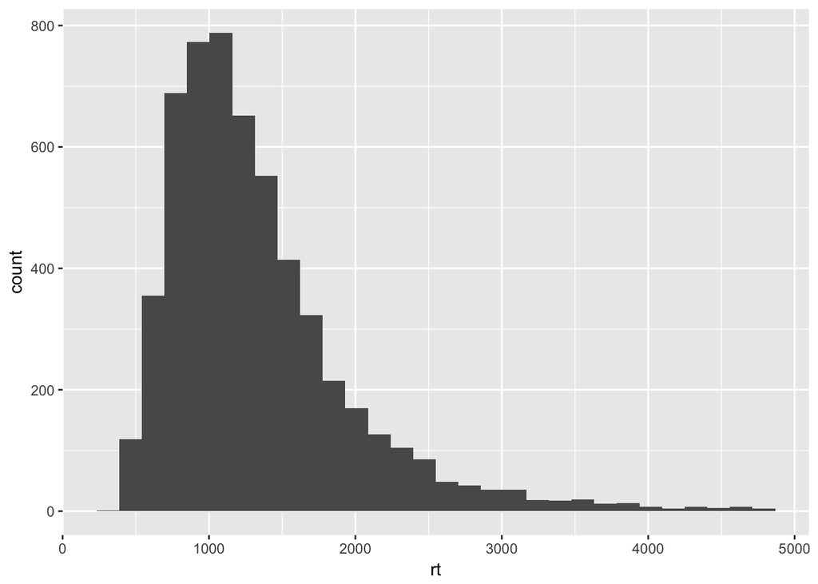

```r
d.listeners.c$log.rt<-log(d.listeners.c$rt)

#trim outliers outside 3 standard deviations of the log mean
lrt <- d.listeners.c$log.rt
d.listeners.ct <- d.listeners.c[lrt < mean(lrt) + 3*sd(lrt) & lrt > mean(lrt) - 3*sd(lrt),]

qplot(data=d.listeners.ct, x=rt, geom = "histogram")
```

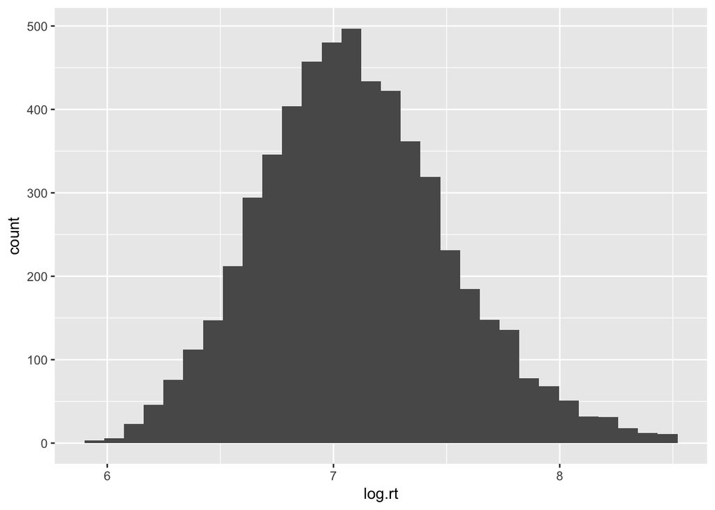

```r
qplot(data=d.listeners.ct, x=log.rt, geom = "histogram")
```

n = 186 participants in listener condition.

### Listener Plots

```r
ms.listeners <- d.listeners.ct %>%
  group_by(subid, text.condition, recode.context, truth.value) %>%
  summarise(rt = mean(rt)) %>%
  group_by(text.condition, recode.context, truth.value) %>%
  summarise(cih = ci.high(rt),
            cil = ci.low(rt),
            rt = mean(rt))

names(ms.listeners) <- c("sentence.type","context","truth.value","rt.cih","rt.cil","rt")
ms.listeners$sentence.type <- factor(ms.listeners$sentence.type, levels = c("Negative", "Positive"))

kable(ms.listeners, digits = 2)
```

| sentence.type | context | truth.value | rt.cih | rt.cil | rt |
| --- | --- | --- | --- | --- | --- |
| Positive | 0/4 | FALSE | 1640.78 | 1452.93 | 1542.43 |
| Positive | 1/4 | FALSE | 1387.16 | 1239.12 | 1314.22 |
| Positive | 1/4 | TRUE | 1219.17 | 1080.64 | 1149.19 |
| Positive | 2/4 | FALSE | 1462.74 | 1300.05 | 1380.60 |
| Positive | 2/4 | TRUE | 1248.20 | 1107.23 | 1174.98 |
| Positive | 3/4 | FALSE | 1414.99 | 1252.15 | 1331.40 |
| Positive | 3/4 | TRUE | 1254.72 | 1110.94 | 1181.91 |
| Positive | 4/4 | TRUE | 1329.03 | 1172.21 | 1248.52 |
| Negative | 0/4 | TRUE | 1759.30 | 1597.84 | 1673.34 |
| Negative | 1/4 | FALSE | 1350.11 | 1180.87 | 1261.04 |
| Negative | 1/4 | TRUE | 1432.73 | 1293.61 | 1360.13 |
| Negative | 2/4 | FALSE | 1433.45 | 1281.32 | 1358.60 |
| Negative | 2/4 | TRUE | 1469.46 | 1315.67 | 1391.80 |
| Negative | 3/4 | FALSE | 1422.97 | 1268.87 | 1342.56 |
| Negative | 3/4 | TRUE | 1439.05 | 1276.93 | 1352.41 |
| Negative | 4/4 | FALSE | 1398.81 | 1243.41 | 1320.76 |

Plot reaction time; compare to Figure 4 in paper:

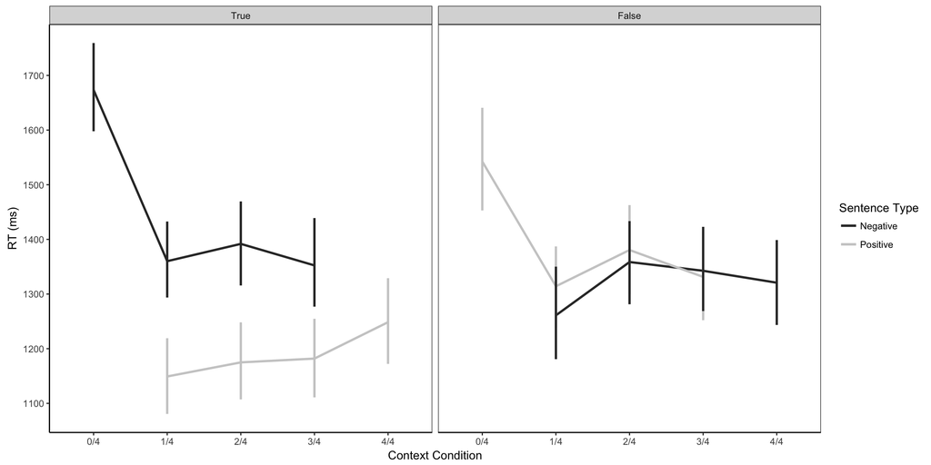

```r
#quartz()
ms.listeners$truth.value <- factor(ms.listeners$truth.value, levels = c(TRUE, FALSE), labels = c("True", "False"))

ggplot(data = subset(ms.listeners), aes(colour = sentence.type, y = rt, x = context)) +
  geom_line(aes(group = sentence.type), size = 1) +
  geom_errorbar(aes(ymin = rt.cil, ymax = rt.cih), width = 0, size = 1) +
  facet_wrap(~truth.value) +
  scale_y_continuous(name = "RT (ms)", breaks = seq(1000, 2000, 100)) +
  xlab("Context Condition") +
  scale_colour_grey("Sentence Type") +
  plot.style
```

### Listener Models

First, recode context in two ways. numeric.context is the numeric proportion of characters with target items in the context. dummy.context compares the 0/4 context to all other contexts.

```r
d.listeners.ct$truth.value <- factor(d.listeners.ct$truth.value,levels = c("FALSE","TRUE"))
d.listeners.ct$numeric.context <- as.numeric(as.character(factor(d.listeners.ct$recode.context, levels = c("0/4","1/4","2/4","3/4","4/4"), labels = c("0",".25",".5",".75","1"))))

d.listeners.ct$dummy.context <- 0
d.listeners.ct[d.listeners.ct$recode.context == "0/4",]$dummy.context <- 1
```

Look at interaction between context, sentence type, and truth value; compare to Table 1 in paper.

```r
model1 <- lmer(rt ~ text.condition*truth.value*numeric.context
       + (text.condition*truth.value |subid)
       + (text.condition*truth.value |item),
       data = d.listeners.ct)
kable(summary(model1)$coefficients, digits = 2)
```

|  | Estimate | Std. Error | t value |
| --- | --- | --- | --- |
| (Intercept) | 1482.80 | 42.04 | 35.27 |
| text.conditionNegative | -205.15 | 37.22 | -5.51 |
| truth.valueTRUE | -371.32 | 37.11 | -10.01 |
| numeric.context | -237.61 | 43.17 | -5.50 |
| text.conditionNegative:truth.valueTRUE | 691.36 | 53.22 | 12.99 |
| text.conditionNegative:numeric.context | 310.39 | 60.93 | 5.09 |
| truth.valueTRUE:numeric.context | 366.20 | 60.63 | 6.04 |
| text.conditionNegative:truth.valueTRUE:numeric.context | -838.28 | 86.65 | -9.67 |

Effect of context on true negative sentences:

```r
model2 <- lmer(rt ~ dummy.context + numeric.context
               + (dummy.context + numeric.context | subid)
               + (dummy.context + numeric.context  | item),
               data = subset(d.listeners.ct, text.condition == "Negative" & truth.value == TRUE))

kable(summary(model2)$coefficients, digits = 2)
```

|  | Estimate | Std. Error | t value |
| --- | --- | --- | --- |
| (Intercept) | 1371.56 | 49.53 | 27.69 |
| dummy.context | 331.31 | 54.05 | 6.13 |
| numeric.context | -4.01 | 74.28 | -0.05 |

```r
model3 <- lmer(rt ~ numeric.context
               + (numeric.context | subid)
               + (numeric.context | item),
               data = subset(d.listeners.ct, text.condition == "Positive" & truth.value == TRUE))
kable(summary(model3)$coefficients, digits = 2)
```

|  | Estimate | Std. Error | t value |
| --- | --- | --- | --- |
| (Intercept) | 1113.84 | 44.28 | 25.15 |
| numeric.context | 123.29 | 54.24 | 2.27 |

## Compare Speakers and Listeners

Only look at true sentences:

```r
ms.listeners <- ms.listeners[ms.listeners$truth.value == TRUE,]
ms.listeners <- ms.listeners[,c("context","sentence.type","rt","rt.cih","rt.cil")]

ms.speakers <- subset(ms.speakers, (sentence.type == "Negative" & trial.type == "nothing") | (sentence.type == "Positive" & trial.type == "item"))
```

Calculate surprisal for speakers:

```r
ms.speakers$surprisal <- -log(ms.speakers$m)
ms.speakers$surprisal.cih <- -log(ms.speakers$m.cih)
ms.speakers$surprisal.cil <- -log(ms.speakers$m.cil)

ms.speakers <- ms.speakers[,c("context","sentence.type","surprisal","surprisal.cih","surprisal.cil")]
```

Merge together:

```r
data.ms <- merge(ms.listeners, ms.speakers)
```

Correlation between RT and surprisal, with and without 0/4 context:

```r
cor.test(data.ms$rt, data.ms$surprisal)
```

```
##
##  Pearson's product-moment correlation
##
## data:  data.ms$rt and data.ms$surprisal
## t = 7.1134, df = 6, p-value = 0.0003881
## alternative hypothesis: true correlation is not equal to 0
## 95 percent confidence interval:
##  0.7216743 0.9903427
## sample estimates:
##       cor
## 0.9455123
```

```r
data.trimmed <- subset(data.ms, context != "0/4")
cor.test(data.trimmed$rt, data.trimmed$surprisal)
```

```
##
##  Pearson's product-moment correlation
##
## data:  data.trimmed$rt and data.trimmed$surprisal
## t = 6.2994, df = 5, p-value = 0.001483
## alternative hypothesis: true correlation is not equal to 0
## 95 percent confidence interval:
##  0.6521371 0.9916789
## sample estimates:
##       cor
## 0.9423901
```

Plot correlation; compare to Figure 5 in paper:

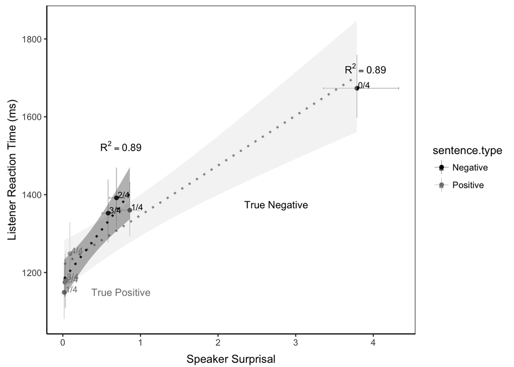

```r
ggplot(data.ms, aes(color=sentence.type, y=rt, x=surprisal)) +
  geom_pointrange(aes(ymin=rt.cil, ymax=rt.cih), size=.1) +
  geom_errorbarh(aes(xmin=surprisal.cil, xmax=surprisal.cih), size=.1) +
  geom_point(aes(color=sentence.type)) +
  geom_smooth(method="lm", lty="dotted", color="grey60", fill="grey90") +
  geom_smooth(data=data.trimmed, method="lm", lty="dotted", color="gray10", fill="gray30") +
  geom_text(aes(label=data.ms$context), hjust=-0.1, vjust=0, size=3) +
  annotate("text", x=.75, y=1525, label="R^2 == .89", parse=TRUE, color="black", size=3.5) +
  annotate("text", x=3.9, y=1725, label="R^2 == .89", parse=TRUE, color="black", size=3.5) +
  annotate("text", x=.75, y=1150, label="True Positive", color="grey50", size=3.5) +
  annotate("text", x=2.75, y=1375, label="True Negative", color="black", size=3.5) +
  ylab("Listener Reaction Time (ms)") +  xlab("Speaker Surprisal") +
  scale_colour_manual(values=c("black","grey50")) +
  plot.style
```